# Project: An Analysis of 10,000+ Movies in The Movie Database (TMDB)

- Introduction
- Data Wrangling
- Exploratory Data Analysis
- Conclusions

## Introduction

This project is an exploratory analysis of over 10,000+ movies in The Movie Database (TMDB) over a span of 55 years between 1960 and 2015. In this analysis we'll explore the trends behind some of the most popular movies and the actors, directors and movies studios behind them.

To kickstart our analysis, we'll import some of the libraries that will be useful in wrangling and visualizing our data.

```python
# Loading libraries and data import
import numpy as np
import pandas as pd
import matplotlib.pyplot as plt
import seaborn as sns
%matplotlib inline
```

## Data Wrangling

### General Properties

First we'll import our dataset and preview its structure.

```python
# Data Import
df = pd.read_csv('tmdb-movies.csv', parse_dates = ['release_date'])
df.head()
```

|  | id | imdb_id | popularity | budget | revenue | original_title | cast | homepage | director | tagline | ... | overview | runtime | genres | production_companies | release_date | vote_count | vote_average | release_year | budget_adj | revenue_adj |
| --- | --- | --- | --- | --- | --- | --- | --- | --- | --- | --- | --- | --- | --- | --- | --- | --- | --- | --- | --- | --- | --- |
| 0 | 135397 | tt0369610 | 32.985763 | 150000000 | 1513528810 | Jurassic World | Chris Pratt\|Bryce Dallas Howard\|Irrfan Khan\|Vi... | http://www.jurassicworld.com/ | Colin Trevorrow | The park is open. | ... | Twenty-two years after the events of Jurassic ... | 124 | Action\|Adventure\|Science Fiction\|Thriller | Universal Studios\|Amblin Entertainment\|Legenda... | 2015-06-09 | 5562 | 6.5 | 2015 | 1.379999e+08 | 1.392446e+09 |
| 1 | 76341 | tt1392190 | 28.419936 | 150000000 | 378436354 | Mad Max: Fury Road | Tom Hardy\|Charlize Theron\|Hugh Keays-Byrne\|Nic... | http://www.madmaxmovie.com/ | George Miller | What a Lovely Day. | ... | An apocalyptic story set in the furthest reach... | 120 | Action\|Adventure\|Science Fiction\|Thriller | Village Roadshow Pictures\|Kennedy Miller Produ... | 2015-05-13 | 6185 | 7.1 | 2015 | 1.379999e+08 | 3.481613e+08 |
| 2 | 262500 | tt2908446 | 13.112507 | 110000000 | 295238201 | Insurgent | Shailene Woodley\|Theo James\|Kate Winslet\|Ansel... | http://www.thedivergentseries.movie/#insurgent | Robert Schwentke | One Choice Can Destroy You | ... | Beatrice Prior must confront her inner demons ... | 119 | Adventure\|Science Fiction\|Thriller | Summit Entertainment\|Mandeville Films\|Red Wago... | 2015-03-18 | 2480 | 6.3 | 2015 | 1.012000e+08 | 2.716190e+08 |
| 3 | 140607 | tt2488496 | 11.173104 | 200000000 | 2068178225 | Star Wars: The Force Awakens | Harrison Ford\|Mark Hamill\|Carrie Fisher\|Adam D... | http://www.starwars.com/films/star-wars-episod... | J.J. Abrams | Every generation has a story. | ... | Thirty years after defeating the Galactic Empi... | 136 | Action\|Adventure\|Science Fiction\|Fantasy | Lucasfilm\|Truenorth Productions\|Bad Robot | 2015-12-15 | 5292 | 7.5 | 2015 | 1.839999e+08 | 1.902723e+09 |
| 4 | 168259 | tt2820852 | 9.335014 | 190000000 | 1506249360 | Furious 7 | Vin Diesel\|Paul Walker\|Jason Statham\|Michelle ... | http://www.furious7.com/ | James Wan | Vengeance Hits Home | ... | Deckard Shaw seeks revenge against Dominic Tor... | 137 | Action\|Crime\|Thriller | Universal Pictures\|Original Film\|Media Rights ... | 2015-04-01 | 2947 | 7.3 | 2015 | 1.747999e+08 | 1.385749e+09 |

5 rows × 21 columns

```python
df.tail()
```

|  | id | imdb_id | popularity | budget | revenue | original_title | cast | homepage | director | tagline | ... | overview | runtime | genres | production_companies | release_date | vote_count | vote_average | release_year | budget_adj | revenue_adj |
| --- | --- | --- | --- | --- | --- | --- | --- | --- | --- | --- | --- | --- | --- | --- | --- | --- | --- | --- | --- | --- | --- |
| 10861 | 21 | tt0060371 | 0.080598 | 0 | 0 | The Endless Summer | Michael Hynson\|Robert August\|Lord 'Tally Ho' B... | NaN | Bruce Brown | NaN | ... | The Endless Summer, by Bruce Brown, is one of ... | 95 | Documentary | Bruce Brown Films | 2066-06-15 | 11 | 7.4 | 1966 | 0.000000 | 0.0 |
| 10862 | 20379 | tt0060472 | 0.065543 | 0 | 0 | Grand Prix | James Garner\|Eva Marie Saint\|Yves Montand\|Tosh... | NaN | John Frankenheimer | Cinerama sweeps YOU into a drama of speed and ... | ... | Grand Prix driver Pete Aron is fired by his te... | 176 | Action\|Adventure\|Drama | Cherokee Productions\|Joel Productions\|Douglas ... | 2066-12-21 | 20 | 5.7 | 1966 | 0.000000 | 0.0 |
| 10863 | 39768 | tt0060161 | 0.065141 | 0 | 0 | Beregis Avtomobilya | Innokentiy Smoktunovskiy\|Oleg Efremov\|Georgi Z... | NaN | Eldar Ryazanov | NaN | ... | An insurance agent who moonlights as a carthie... | 94 | Mystery\|Comedy | Mosfilm | 2066-01-01 | 11 | 6.5 | 1966 | 0.000000 | 0.0 |
| 10864 | 21449 | tt0061177 | 0.064317 | 0 | 0 | What's Up, Tiger Lily? | Tatsuya Mihashi\|Akiko Wakabayashi\|Mie Hama\|Joh... | NaN | Woody Allen | WOODY ALLEN STRIKES BACK! | ... | In comic Woody Allen's film debut, he took the... | 80 | Action\|Comedy | Benedict Pictures Corp. | 2066-11-02 | 22 | 5.4 | 1966 | 0.000000 | 0.0 |
| 10865 | 22293 | tt0060666 | 0.035919 | 19000 | 0 | Manos: The Hands of Fate | Harold P. Warren\|Tom Neyman\|John Reynolds\|Dian... | NaN | Harold P. Warren | It's Shocking! It's Beyond Your Imagination! | ... | A family gets lost on the road and stumbles up... | 74 | Horror | Norm-Iris | 2066-11-15 | 15 | 1.5 | 1966 | 127642.279154 | 0.0 |

5 rows × 21 columns

```python
# Structure of the data
df.shape
```

```
(10866, 21)
```

This tells us that there are 21 columns and 10,866 rows in this dataset.

```python
# Information on column data types and null value count
df.info()
```

```
<class 'pandas.core.frame.DataFrame'>
RangeIndex: 10866 entries, 0 to 10865
Data columns (total 21 columns):
 #   Column                Non-Null Count  Dtype
---  ------                --------------  -----
 0   id                    10866 non-null  int64
 1   imdb_id               10856 non-null  object
 2   popularity            10866 non-null  float64
 3   budget                10866 non-null  int64
 4   revenue               10866 non-null  int64
 5   original_title        10866 non-null  object
 6   cast                  10790 non-null  object
 7   homepage              2936 non-null   object
 8   director              10822 non-null  object
 9   tagline               8042 non-null   object
 10  keywords              9373 non-null   object
 11  overview              10862 non-null  object
 12  runtime               10866 non-null  int64
 13  genres                10843 non-null  object
 14  production_companies  9836 non-null   object
 15  release_date          10866 non-null  datetime64[ns]
 16  vote_count            10866 non-null  int64
 17  vote_average          10866 non-null  float64
 18  release_year          10866 non-null  int64
 19  budget_adj            10866 non-null  float64
 20  revenue_adj           10866 non-null  float64
dtypes: datetime64[ns](1), float64(4), int64(6), object(10)
memory usage: 1.7+ MB
```

We can observe that some of the columns in the dataset including cast, director, keywords, production companies etc. have some null values. These null values will need to be investigated further to determine the best ways to handle them.

The `describe` function gives a good overview of the distribution of the numerical variables in our data.

```python
df.describe()
```

|  | id | popularity | budget | revenue | runtime | vote_count | vote_average | release_year | budget_adj | revenue_adj |
| --- | --- | --- | --- | --- | --- | --- | --- | --- | --- | --- |
| count | 10866.000000 | 10866.000000 | 1.086600e+04 | 1.086600e+04 | 10866.000000 | 10866.000000 | 10866.000000 | 10866.000000 | 1.086600e+04 | 1.086600e+04 |
| mean | 66064.177434 | 0.646441 | 1.462570e+07 | 3.982332e+07 | 102.070863 | 217.389748 | 5.974922 | 2001.322658 | 1.755104e+07 | 5.136436e+07 |
| std | 92130.136561 | 1.000185 | 3.091321e+07 | 1.170035e+08 | 31.381405 | 575.619058 | 0.935142 | 12.812941 | 3.430616e+07 | 1.446325e+08 |
| min | 5.000000 | 0.000065 | 0.000000e+00 | 0.000000e+00 | 0.000000 | 10.000000 | 1.500000 | 1960.000000 | 0.000000e+00 | 0.000000e+00 |
| 25% | 10596.250000 | 0.207583 | 0.000000e+00 | 0.000000e+00 | 90.000000 | 17.000000 | 5.400000 | 1995.000000 | 0.000000e+00 | 0.000000e+00 |
| 50% | 20669.000000 | 0.383856 | 0.000000e+00 | 0.000000e+00 | 99.000000 | 38.000000 | 6.000000 | 2006.000000 | 0.000000e+00 | 0.000000e+00 |
| 75% | 75610.000000 | 0.713817 | 1.500000e+07 | 2.400000e+07 | 111.000000 | 145.750000 | 6.600000 | 2011.000000 | 2.085325e+07 | 3.369710e+07 |
| max | 417859.000000 | 32.985763 | 4.250000e+08 | 2.781506e+09 | 900.000000 | 9767.000000 | 9.200000 | 2015.000000 | 4.250000e+08 | 2.827124e+09 |

From the `describe` function's output, we can observe that the budget and revenue columns alongside their adjusted columns, have median values of zero. This means that at least half of the observations in this dataset contain zero in the fields for budget or revenue.

Let's also get a visual overview of the untouched data.

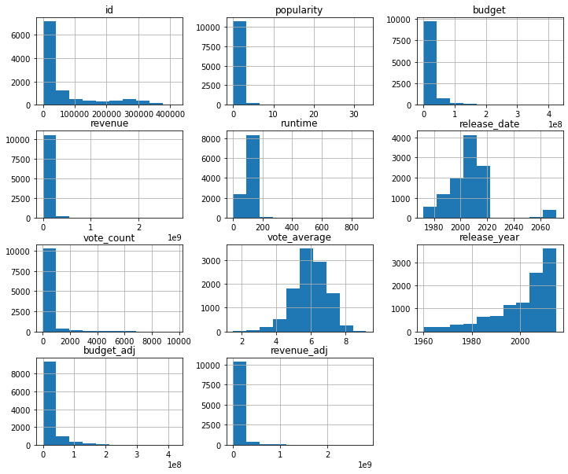

```python
df.hist(figsize=(12,10));
```

We can observe the same trend of the high frequency of zero values seen in the summary table above.

### Data Cleaning

To begin our data cleaning we'll drop all the extraneous columns irrelevant to our analysis.

```python
# Dropping extraneous columns
df.drop(['id', 'imdb_id', 'homepage', 'tagline', 'keywords', 'overview'], axis = 1, inplace = True)
```

Having dropped the extraneous columns, next we check for duplicate entries in our data

```python
# Checking for Duplicate Entries
df.duplicated().sum()
```

```
1
```

There is one duplicate entry which we'll clean up using the `drop_duplicates` function.

```python
# Cleaning Duplicates
df.drop_duplicates(inplace = True)
df.duplicated().sum()
```

```
0
```

The duplicate entry has been dropped and we can verify there are no more duplicates present in the dataset.

Next, we'll address the issue of the zero values in the `runtime`, `budget`, `budget_adj`, `revenue` and `revenue_adj` columns. The [data source](https://www.kaggle.com/datasets/tmdb/tmdb-movie-metadata) suggests that the zero values in the budget and revenue fields should be treated as missing. Let's replace these zero values with a null value so they do not skew our analysis.

```python
# Filling null values
df = df.replace(0, np.NaN)
df.describe()
```

|  | popularity | budget | revenue | runtime | vote_count | vote_average | release_year | budget_adj | revenue_adj |
| --- | --- | --- | --- | --- | --- | --- | --- | --- | --- |
| count | 10865.000000 | 5.169000e+03 | 4.849000e+03 | 10834.000000 | 10865.000000 | 10865.000000 | 10865.000000 | 5.169000e+03 | 4.849000e+03 |
| mean | 0.646446 | 3.073958e+07 | 8.923886e+07 | 102.363855 | 217.399632 | 5.975012 | 2001.321859 | 3.688907e+07 | 1.151009e+08 |
| std | 1.000231 | 3.890441e+07 | 1.620801e+08 | 30.948225 | 575.644627 | 0.935138 | 12.813260 | 4.196096e+07 | 1.988557e+08 |
| min | 0.000065 | 1.000000e+00 | 2.000000e+00 | 2.000000 | 10.000000 | 1.500000 | 1960.000000 | 9.210911e-01 | 2.370705e+00 |
| 25% | 0.207575 | 6.000000e+06 | 7.732325e+06 | 90.000000 | 17.000000 | 5.400000 | 1995.000000 | 8.102293e+06 | 1.046585e+07 |
| 50% | 0.383831 | 1.700000e+07 | 3.185308e+07 | 99.000000 | 38.000000 | 6.000000 | 2006.000000 | 2.271505e+07 | 4.395666e+07 |
| 75% | 0.713857 | 4.000000e+07 | 9.996575e+07 | 112.000000 | 146.000000 | 6.600000 | 2011.000000 | 5.008384e+07 | 1.316482e+08 |
| max | 32.985763 | 4.250000e+08 | 2.781506e+09 | 900.000000 | 9767.000000 | 9.200000 | 2015.000000 | 4.250000e+08 | 2.827124e+09 |

We can observe the increase in the **mean** of the `budget` and `revenue` fields from USD 14,625,700 to USD 30,739,580 and USD 39,823,320 to USD 89,238,860 respectively. Likewise, the **median** values going from zero to USD 17,000,000 and USD 31,850,800 respectively.

These numbers are more indicative of the central tendencies of the dataset now that the zero values have been replaced.

## Exploratory Data Analysis

### Research Question 1: How Do The Different Movie Genres Perform?

Let's explore the performance of movie genres on different criteria in this dataset.

#### Analysis of Movie Genres

What movie genres are present in this dataset? To find out this information, we need to extract the individual genres that are concatenated in the `genres` field of each movie. To do this, we'll use the `split` and `explode` methods.

```python
genres_df = df.assign(genres = df['genres'].str.split('|')).explode('genres')
genres_df.head(10)
```

|  | popularity | budget | revenue | original_title | cast | director | runtime | genres | production_companies | release_date | vote_count | vote_average | release_year | budget_adj | revenue_adj |
| --- | --- | --- | --- | --- | --- | --- | --- | --- | --- | --- | --- | --- | --- | --- | --- |
| 0 | 32.985763 | 150000000.0 | 1.513529e+09 | Jurassic World | Chris Pratt\|Bryce Dallas Howard\|Irrfan Khan\|Vi... | Colin Trevorrow | 124.0 | Action | Universal Studios\|Amblin Entertainment\|Legenda... | 2015-06-09 | 5562 | 6.5 | 2015 | 1.379999e+08 | 1.392446e+09 |
| 0 | 32.985763 | 150000000.0 | 1.513529e+09 | Jurassic World | Chris Pratt\|Bryce Dallas Howard\|Irrfan Khan\|Vi... | Colin Trevorrow | 124.0 | Adventure | Universal Studios\|Amblin Entertainment\|Legenda... | 2015-06-09 | 5562 | 6.5 | 2015 | 1.379999e+08 | 1.392446e+09 |
| 0 | 32.985763 | 150000000.0 | 1.513529e+09 | Jurassic World | Chris Pratt\|Bryce Dallas Howard\|Irrfan Khan\|Vi... | Colin Trevorrow | 124.0 | Science Fiction | Universal Studios\|Amblin Entertainment\|Legenda... | 2015-06-09 | 5562 | 6.5 | 2015 | 1.379999e+08 | 1.392446e+09 |
| 0 | 32.985763 | 150000000.0 | 1.513529e+09 | Jurassic World | Chris Pratt\|Bryce Dallas Howard\|Irrfan Khan\|Vi... | Colin Trevorrow | 124.0 | Thriller | Universal Studios\|Amblin Entertainment\|Legenda... | 2015-06-09 | 5562 | 6.5 | 2015 | 1.379999e+08 | 1.392446e+09 |
| 1 | 28.419936 | 150000000.0 | 3.784364e+08 | Mad Max: Fury Road | Tom Hardy\|Charlize Theron\|Hugh Keays-Byrne\|Nic... | George Miller | 120.0 | Action | Village Roadshow Pictures\|Kennedy Miller Produ... | 2015-05-13 | 6185 | 7.1 | 2015 | 1.379999e+08 | 3.481613e+08 |
| 1 | 28.419936 | 150000000.0 | 3.784364e+08 | Mad Max: Fury Road | Tom Hardy\|Charlize Theron\|Hugh Keays-Byrne\|Nic... | George Miller | 120.0 | Adventure | Village Roadshow Pictures\|Kennedy Miller Produ... | 2015-05-13 | 6185 | 7.1 | 2015 | 1.379999e+08 | 3.481613e+08 |
| 1 | 28.419936 | 150000000.0 | 3.784364e+08 | Mad Max: Fury Road | Tom Hardy\|Charlize Theron\|Hugh Keays-Byrne\|Nic... | George Miller | 120.0 | Science Fiction | Village Roadshow Pictures\|Kennedy Miller Produ... | 2015-05-13 | 6185 | 7.1 | 2015 | 1.379999e+08 | 3.481613e+08 |
| 1 | 28.419936 | 150000000.0 | 3.784364e+08 | Mad Max: Fury Road | Tom Hardy\|Charlize Theron\|Hugh Keays-Byrne\|Nic... | George Miller | 120.0 | Thriller | Village Roadshow Pictures\|Kennedy Miller Produ... | 2015-05-13 | 6185 | 7.1 | 2015 | 1.379999e+08 | 3.481613e+08 |
| 2 | 13.112507 | 110000000.0 | 2.952382e+08 | Insurgent | Shailene Woodley\|Theo James\|Kate Winslet\|Ansel... | Robert Schwentke | 119.0 | Adventure | Summit Entertainment\|Mandeville Films\|Red Wago... | 2015-03-18 | 2480 | 6.3 | 2015 | 1.012000e+08 | 2.716190e+08 |
| 2 | 13.112507 | 110000000.0 | 2.952382e+08 | Insurgent | Shailene Woodley\|Theo James\|Kate Winslet\|Ansel... | Robert Schwentke | 119.0 | Science Fiction | Summit Entertainment\|Mandeville Films\|Red Wago... | 2015-03-18 | 2480 | 6.3 | 2015 | 1.012000e+08 | 2.716190e+08 |

The results give us an observation for each unique genre a movie was classified by. Next, we want to know how many unique genre classifications exist in the dataset.

```python
genres_df['genres'].nunique()
```

```
20
```

There are 20 unique genres present in the dataset. Let's visualize this data to see the highest occurring movie genres.

```
''
```

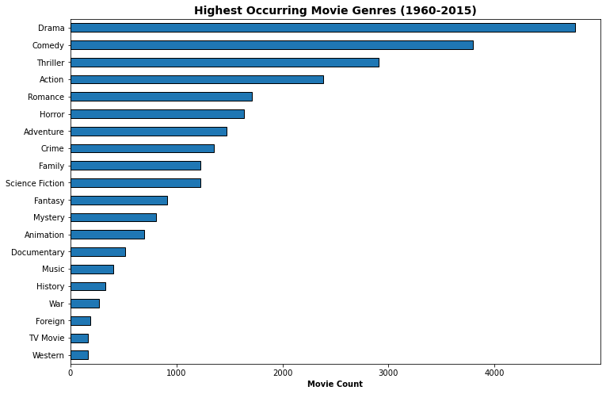

```python
genre_count = genres_df.groupby('genres').size().sort_values()
genre_count.plot.barh(figsize = (12,8), edgecolor='black')
plt.title('Highest Occurring Movie Genres (1960-2015)', fontsize=14, weight="bold")
plt.ylabel(None)
plt.xlabel('Movie Count', fontsize=10, weight="bold")
;
```

The Drama genre is the highest occurring genre within this time period, followed by the Comedy and Thriller genres. Westerns, TV Movie and Foreign are the bottom 3 occurring genres in that order.

Next, let's explore the average budget spend on movies from each genre.

```
''
```

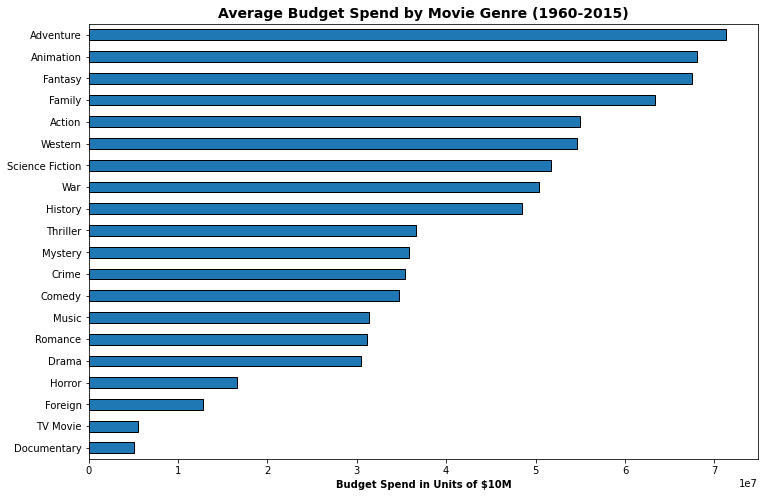

```python
avg_budget_spend = genres_df.groupby('genres')['budget_adj'].mean().sort_values()
avg_budget_spend.plot.barh(figsize = (12,8), edgecolor='black')
plt.title('Average Budget Spend by Movie Genre (1960-2015)', fontsize=14, weight="bold")
plt.ylabel(None)
plt.xlabel('Budget Spend in Units of $10M', fontsize=10, weight="bold")
;
```

The Adventure, Animation and Fantasy genres had the highest budget spend on average while Documentary, Foreign and TV Movie have the lowest amount spent on budgets.

```
''
```

[figure not shown]

```python
avg_budget_spend = genres_df.groupby('genres')['revenue_adj'].mean().sort_values()
avg_budget_spend.plot.barh(figsize = (12,8), edgecolor='black')
plt.title('Average Revenue by Movie Genre', fontsize=14, weight="bold")
plt.ylabel(None)
plt.xlabel('Revenue Grossed in Units of $10M', fontsize=10, weight="bold")
;
```

From the chart, we can see that the Animation, Adventure and Fantasy genres grossed the highest revenues on average while Documentary, Foreign and TV Movie grossed the lowest revenues of the 20 movie genres.

```
''
```

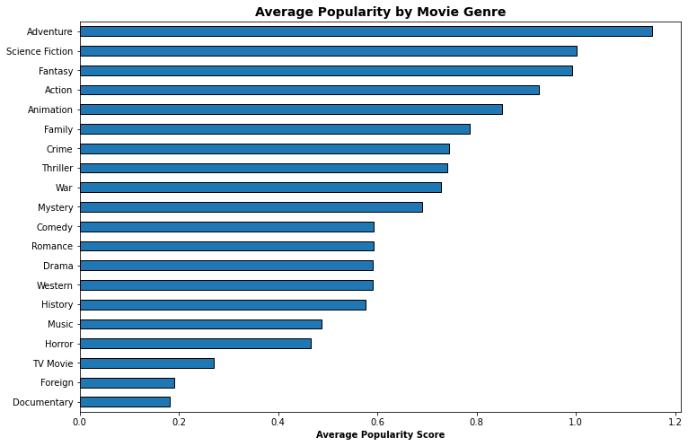

```python
genre_popularity = genres_df.groupby('genres').popularity.mean().sort_values()
genre_popularity.plot.barh(figsize = (12,8), edgecolor='black')
plt.title('Average Popularity by Movie Genre', fontsize=14, weight="bold")
plt.ylabel(None)
plt.xlabel('Average Popularity Score', fontsize=10, weight="bold")
;
```

From the average popularity scores on the chart, *Adventure*, *Science Fiction* and *Fantasy* are the most popular movie genres searched for or interacted with by users of the TMDB website. On the other end of the spectrum, the *Documentary*, *Foreign* and *TV Movie* movie genres are the least popular among TMDB users.

```python
genre_by_year = genres_df.groupby(['release_year', 'genres']).size()
max_genre_count = genre_by_year.groupby(level='release_year').transform('max')
genre_by_year
```

```
release_year  genres
1960          Action               8
              Adventure            5
              Comedy               8
              Crime                2
              Drama               13
                                ...
2015          Science Fiction     86
              TV Movie            20
              Thriller           171
              War                  9
              Western              6
Length: 1049, dtype: int64
```

```python
max_genre_by_year = genre_by_year[genre_by_year == max_genre_count]
max_genre_by_year
```

```
release_year  genres
1960          Drama      13
1961          Drama      16
1962          Drama      21
1963          Comedy     13
              Drama      13
1964          Drama      20
1965          Drama      20
1966          Comedy     16
              Drama      16
1967          Comedy     17
1968          Drama      20
1969          Drama      13
1970          Drama      19
1971          Drama      30
```

[output cut: 45 more lines]

```python
max_genre_by_year.groupby(level=1).count()
```

```
genres
Comedy    10
Drama     48
dtype: int64
```

From our data, we can see that the Drama genre is the most common type of movie released on a yearly basis. In the period spanned by this dataset, the Drama genre was the most prolific genre for 48 years versus the Comedy genre's 10 years.

The sheer number of datapoints make it difficult to visualize this data all at once, so we'll view the first 10 years of the data.

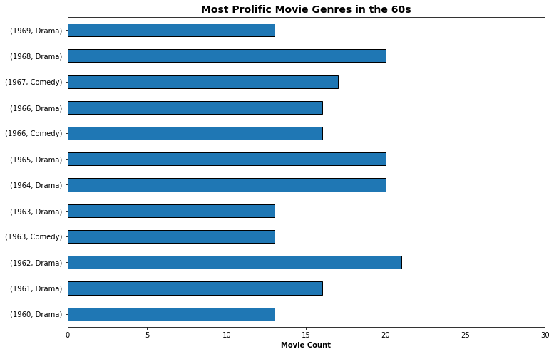

```python
max_genre_by_year.iloc[:12].plot.barh(figsize = (12,8), edgecolor='black', xticks = np.arange(0,31,5))
plt.title('Most Prolific Movie Genres in the 60s', fontsize=14, weight="bold")
plt.ylabel(None)
plt.xlabel('Movie Count', fontsize=10, weight="bold");
```

Zooming out, let's look at the genres with the highest amount of movies releases through the different decades. First, we'll need to use the `release_year` field to categorize our data into decades.

```python
# Grouping Release Year into Decades
labels = ["{0} - {1}".format(i, i + 9) for i in range(1960, 2020, 10)]
genres_df["decade"] = pd.cut(genres_df.release_year, range(1960, 2021, 10), right=False, labels=labels)

genres_df.sample(5)
```

|  | popularity | budget | revenue | original_title | cast | director | runtime | genres | production_companies | release_date | vote_count | vote_average | release_year | budget_adj | revenue_adj | decade |
| --- | --- | --- | --- | --- | --- | --- | --- | --- | --- | --- | --- | --- | --- | --- | --- | --- |
| 6197 | 3.087036 | 50000000.0 | 104478416.0 | The Hitchhiker's Guide to the Galaxy | Martin Freeman\|Zooey Deschanel\|Sam Rockwell\|Mo... | Garth Jennings | 109.0 | Comedy | Spyglass Entertainment\|Everyman Pictures\|Hamme... | 2005-01-15 | 780 | 6.6 | 2005 | 5.582816e+07 | 1.166568e+08 | 2000 - 2009 |
| 7003 | 1.433373 | NaN | 181466833.0 | Scooby-Doo 2: Monsters Unleashed | Freddie Prinze Jr.\|Sarah Michelle Gellar\|Matth... | Raja Gosnell | 93.0 | Adventure | Mosaic Media Group\|Warner Bros. | 2004-03-24 | 263 | 5.2 | 2004 | NaN | 2.094936e+08 | 2000 - 2009 |
| 5477 | 1.483329 | 30000000.0 | 36894225.0 | The Family | Robert De Niro\|Michelle Pfeiffer\|Dianna Agron\|... | Luc Besson | 111.0 | Comedy | Canal Plus\|TF1 Films Production\|Grive Producti... | 2013-09-13 | 710 | 6.1 | 2013 | 2.808100e+07 | 3.453423e+07 | 2010 - 2019 |
| 5198 | 0.126182 | 569217.0 | 569217.0 | Les Clefs de bagnole | Laurent Baffie\|Daniel Russo\|Pascal Sellem\|GÃ©r... | Laurent Baffie | 90.0 | Comedy | Laurent Baffie Productions | 2003-12-10 | 12 | 4.8 | 2003 | 6.747229e+05 | 6.747229e+05 | 2000 - 2009 |
| 7336 | 0.404642 | NaN | NaN | Permanent Vacation | Chris Parker\|Leila Gastil\|Sara Driver\|Charlie ... | Jim Jarmusch | 75.0 | Drama | Cinesthesia Productions | 1980-01-01 | 10 | 6.2 | 1980 | NaN | NaN | 1980 - 1989 |

Having labeled our dataset we can now find the most prolific genres for each decade.

```python
genre_by_decade = genres_df.groupby(['decade', 'genres']).size()
max_genre_decade = genre_by_decade.groupby(level = 'decade').transform('max')
max_genre_decade
```

```
decade       genres
1960 - 1969  Action              168
             Adventure           168
             Animation           168
             Comedy              168
             Crime               168
                                ...
2010 - 2019  Science Fiction    1453
             TV Movie           1453
             Thriller           1453
             War                1453
             Western            1453
Length: 120, dtype: int64
```

```
''
```

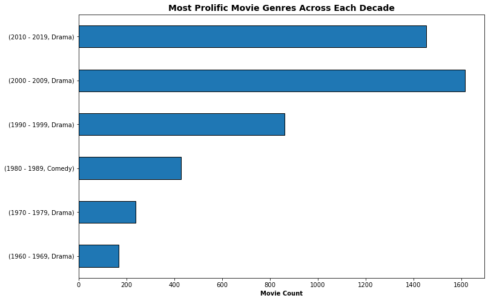

```python
genre_by_decade[genre_by_decade == max_genre_decade].plot.barh(figsize = (12,8), edgecolor='black')
plt.title('Most Prolific Movie Genres Across Each Decade', fontsize=14, weight="bold")
plt.ylabel(None)
plt.xlabel('Movie Count', fontsize=10, weight="bold")
;
```

### Research Question 2: What Impact does Popularity have on Movie Performance?

According to [TMDB](https://developers.themoviedb.org/3/getting-started/popularity), the popularity metric is calculated by algorithms modeled on a different types of user interactions with a movie. For example, the number of views for the day, saves on a watchlist or total votes received etc.

Let's explore the impacts of this popularity metric on some of the most important success metrics of a movie.

#### Revenue

To explore this relationship between we'll use a scatter diagram. Since we'll be plotting a couple of of them, let's define a helper function, `ScatterPlot` for plotting our scatter diagrams.

```python
def ScatterPlot(df, xVar, yVar, title=None, xlabel=None, ylabel=None):
    '''
    This function plots a scatter diagram of two variables within the same dataframe.
    The plot's title and axis labels defaults to the variable names if no user-defined arguments are passed.

    inputs: Dataframe object - df, Dataframe columns - xVar, yVar
    kwargs: Strings - title, xlabel, ylabel
    outputs: Scatter Diagram of xVar and yVar
    '''
    # Plot
    df.plot(kind = 'scatter', x=xVar, y=yVar,  figsize=(14,8), alpha=0.3)

    # Clean up and format labels
    xVar = xVar.replace('_', ' ').title()
    yVar = yVar.replace('_', ' ').title()

    # Plot title and fallback
    if not title:
        plt.title(f'Relationship between {xVar} and {yVar}', fontsize=14, weight="bold")
    else:
        plt.title(title, fontsize=14, weight="bold")

    # Plot y-Axis label and fallback
    if not xlabel:
        plt.xlabel(xVar, fontsize=10, weight="bold")
    else:
        plt.xlabel(xlabel, fontsize=10, weight="bold")

    # Plot y-Axis label and fallback
    if not ylabel:
        plt.ylabel(yVar, fontsize=10, weight="bold")
    else:
        plt.ylabel(ylabel, fontsize=10, weight="bold")
```

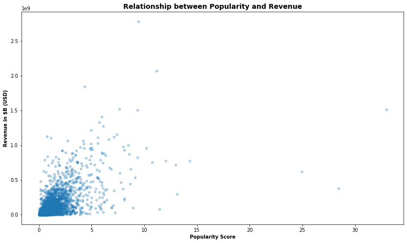

```python
# Calling the ScatterPlot helper function
ScatterPlot(df, 'popularity', 'revenue',  ylabel='Revenue in $B (USD)', xlabel='Popularity Score')
```

The plot above shows us some loose positive correlation between movie revenues and the popularity scores with majority of the datapoints clustered between popularity scores of 0 - 4 and revenue figures of 0 - \$400M as well as some outliers.

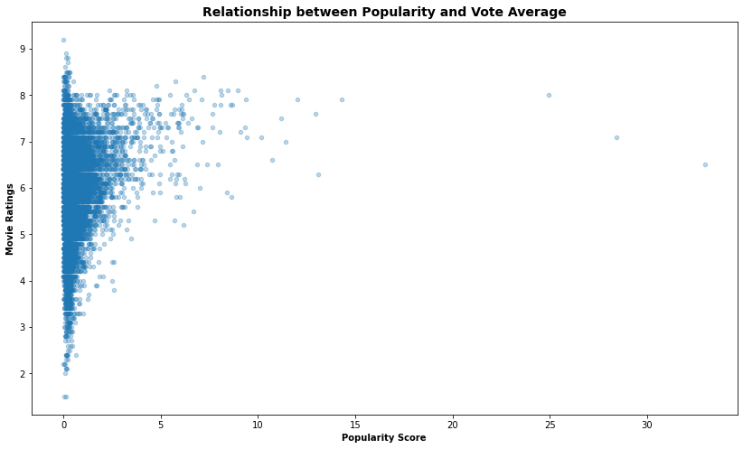

```python
ScatterPlot(df, 'popularity', 'vote_average', ylabel='Movie Ratings', xlabel='Popularity Score')
```

The diagram shows no significant correlation between the TMDB popularity scores and movie ratings but the significant chunk of the data points linearly aligned with the x-axis suggest that movie ratings are largely independent of popularity scores.

## Conclusions

From our analysis of the TMDB dataset, we can deduce the following insights:

1. The Drama, Comedy and Thriller genres are the most prolific genres over the 55 year period spanned by this dataset, while the Westerns, TV Movie and Foreign genres are the least prolific.
2. The Adventure, Animation and Fantasy genres had the highest budgets on average and also grossed the highest revenues on average. This suggests that there seem to be a good correlation between higher movie budgets and box office revenues.
3. Adventure, Science Fiction and Fantasy are the most popular genres with TMDB users, while Documentary, Foreign and TV Movie are the least popular.
4. On a yearly basis, the Drama genre dominated the number of movies released topping the charts for 48 years out of the 55-year span of the data.
5. There is some loose positive correlation between TMDB popularity scores and Movie Revenue.
6. There is no observable correlation between the popularity score of a movie and how high or low it is rated.

### Limitations Of This Analysis

1. The dataset analysed contained a lot of observations that were incomplete or outdated as at the time this analysis was performed.
2. Only exploratory analysis was carried out on this dataset.